# Statistical inference with the GSS data

## Setup

### Load packages

```r
library(ggplot2)
library(dplyr)
library(statsr)
```

### Load data

```r
load("gss.Rdata")
```

## Part 1: Data

[Excerpted from the GSS project description](https://www.norc.org/Research/Projects/Pages/general-social-survey.aspx)

The GSS aims to gather data on contemporary American society in order to monitor and explain trends and constants in attitudes, behaviors, and attributes; to examine the structure and functioning of society in general as well as the role played by relevant subgroups; to compare the United States to other societies in order to place American society in comparative perspective and develop cross-national models of human society; and to make high-quality data easily accessible to scholars, students, policy makers, and others, with minimal cost and waiting.

Therefore we can generalize the result because random sampling was used when gathering the data on contemporary American society. However, we cannot judge the causality from the analysis results because random assignment was not used in the research.

## Part 2: Research question

*Is there any relationship between education level and one of the controversial social issues : Suicide Perspective?*

## Part 3: Exploratory data analysis

*1. Summary : Education & Suicide Perspective*

Description Excerpted from the Coursera Data and Statistical Inference Course

*Education* : What is the highest grade in elementary school or high school that you finished and got credit for?

- Highest year of school completed

*Suicide* : Do you think a person has the right to end his or her own life if this person?

- Q1. suicide1: Suicide if incurable disease
- Q2. suicide2: Suicide if bankrupt
- Q3. suicide3: Suicide if dishonored family
- Q4. suicide4: Suicide if tired of living
- Yes : if any question is answered “Yes”, No : if all 4 questions are answered “No”

Min of education(year) is 0, Max is 20, median is 12 and mean is 12.75.

The group who has positive suicide perspective is 16,260 and the negative is 12,539.

```r
gss_sui <- gss %>%
            select(educ, suicide1, suicide2, suicide3, suicide4) %>%
            mutate(suicide = as.factor(ifelse(suicide1 == "Yes" | suicide2 == "Yes" |
                                      suicide3 == "Yes" | suicide4 == "Yes" , "Yes", "No"))) %>%
            select(educ, suicide)

gss_sui %>% summary()
```

```
##       educ       suicide
##  Min.   : 0.00   No  :12539
##  1st Qu.:12.00   Yes :16260
##  Median :12.00   NA's:28262
##  Mean   :12.75
##  3rd Qu.:15.00
##  Max.   :20.00
##  NA's   :164
```

*2. Histogram*

The distribution of education is nearly normal. (Slighlty left skewed)

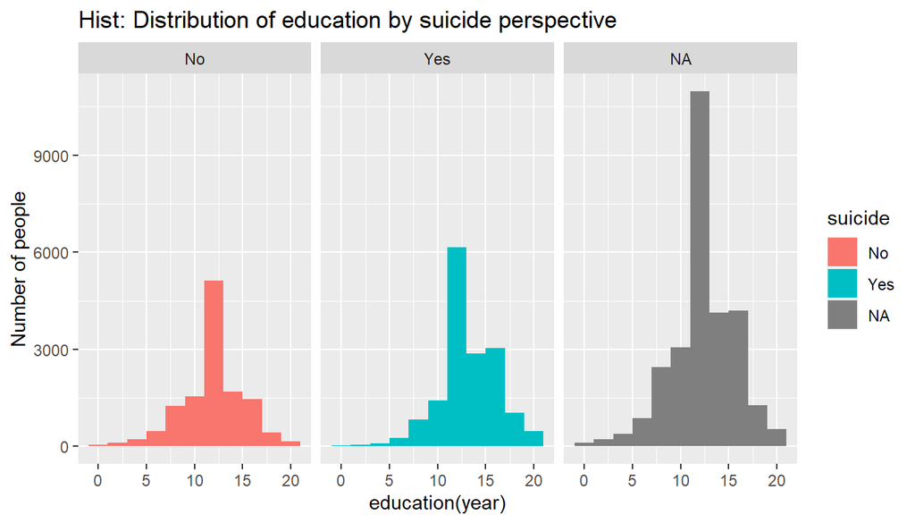

```r
gss_sui %>%
  select(educ, suicide) %>%
  group_by(suicide) %>%
  ggplot(aes(educ, fill = suicide))+
  geom_histogram(binwidth = 2)+
  labs(title = "Hist: Distribution of education by suicide perspective",
       x = "education(year)", y = "Number of people")+
  facet_grid(.~suicide)
```

*3. Box plot*

Median education to group of suicide perspective ‘Yes’ is higher than that of ‘No’

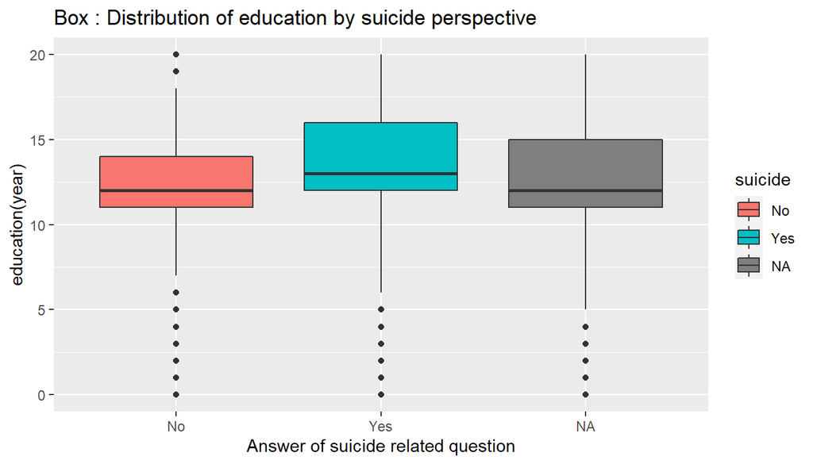

```r
gss_sui %>%
  select(educ, suicide) %>%
  group_by(suicide) %>%
  ggplot(aes(suicide, educ, fill = suicide))+
  geom_boxplot()+
  labs(title = "Box : Distribution of education by suicide perspective",
       x = "Answer of suicide related question", y = "education(year)")
```

*4. Mean*

Mean education to ‘group of suicide perspective ’Yes’ is also higher than that of ‘No’

```r
gss_sui %>%
  select(educ, suicide) %>%
  group_by(suicide) %>%
  summarize(mean_educ = mean(educ, na.rm = TRUE))
```

```
## # A tibble: 3 x 2
##   suicide mean_educ
##   <fct>       <dbl>
## 1 No           12.2
## 2 Yes          13.4
## 3 <NA>         12.6
```

## Part 4: Inference

*Hypothesis test*

1. $H_0: \mu_{suicide} = \mu_{nosuicide}$; $H_A: \mu_{suicide}\ne \mu_{nosuicide}$

```r
inference(y = educ, x = suicide, statistic = "mean", data = gss_sui,
          type = "ht", null = 0, alternative = "twosided", method = "theoretical")
```

```
## Response variable: numerical
## Explanatory variable: categorical (2 levels)
## n_No = 12503, y_bar_No = 12.1736, s_No = 3.1881
## n_Yes = 16224, y_bar_Yes = 13.4405, s_Yes = 2.9588
## H0: mu_No =  mu_Yes
## HA: mu_No != mu_Yes
## t = -34.4502, df = 12502
## p_value = < 0.0001
```

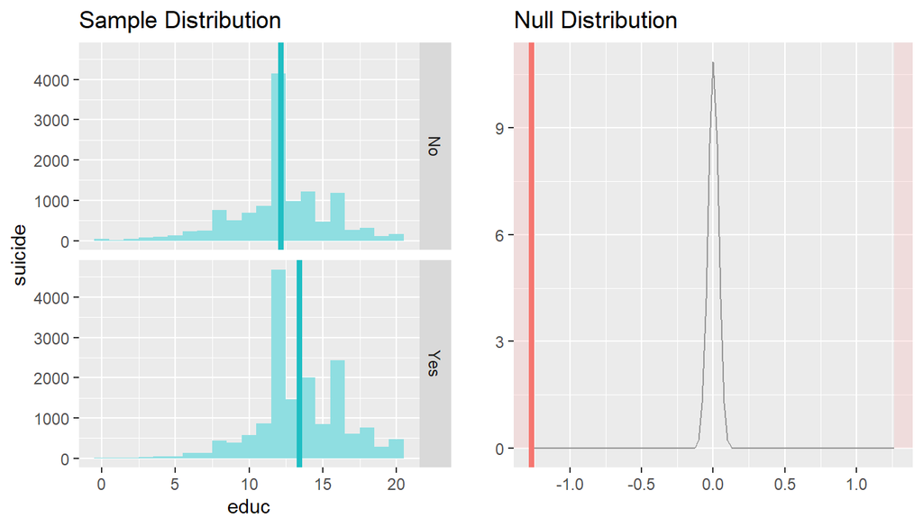

*Confidence Interval*

```r
inference(y = educ, x = suicide, statistic = "mean", data = gss_sui,
          type = "ci", method = "theoretical", order = c("Yes", "No"))
```

```
## Response variable: numerical, Explanatory variable: categorical (2 levels)
## n_Yes = 16224, y_bar_Yes = 13.4405, s_Yes = 2.9588
## n_No = 12503, y_bar_No = 12.1736, s_No = 3.1881
## 95% CI (Yes - No): (1.1949 , 1.339)
```

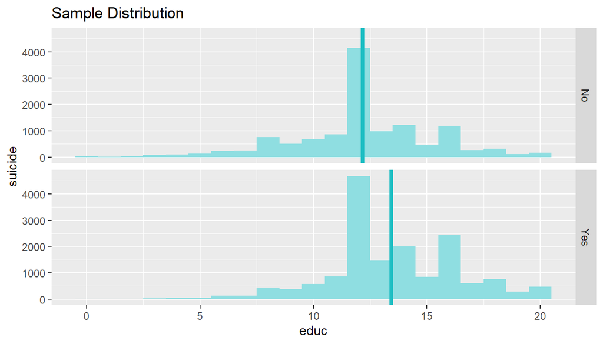

*End of the document.*